# Appendix A: Stationary Ricker to cyclical Beveton-Holt spawner-recruit formulation

B. Connors

July 23, 2019

In our baseline simulations we assumed that recruitment dynamics are governed by stationary spawner-recruitment dynamics that follow a Ricker-type relationship with overcompensation at high spawner abundances (equations 1-3). This is the state of nature that is currently assumed by fishery managers in the Kuskokwim and widely across other salmon fisheries. We also considered an alternative recruitment hypothesis that assumed that low frequency regime shifts occur that gave rise to the appearance of overcompensation, when in fact none was present. Under this hypothesis we assumed that individual spawner-recruitment relationships were governed by Beverton-Holt dynamics with cyclical variation in population productivity (hereafter referred to as “BH_cycl”). This appendix details simulations used to parameterize the BH_cycl formulation in a manner that maintains the general system characteristics of the Kuskokwim.

```
## [1] 1 2
```

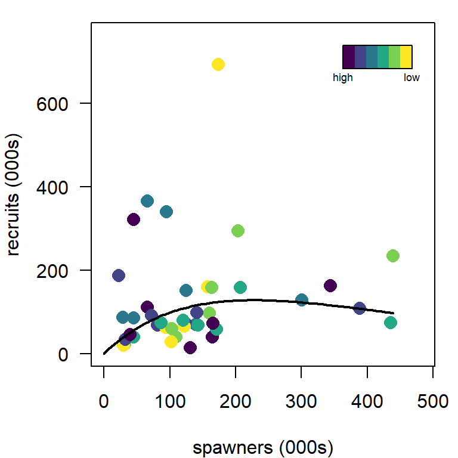

To do this we transformed the Ricker spawner-recruitment relationship in equation 1 to a Beverton-Holt form (Hilborn and Walters 1992) with time varying productivity: